# 로마 제국의 흥망 — 1000년 제국이 남긴 경고문

Culture Voyager #8 | 역사 다큐멘터리

Author

Nakcho Choi

Published

May 16, 2026

## 들어가며 — 왜 자꾸 로마인가

누군가 “로마 제국”이라고 말할 때마다 떠오르는 밈이 있다. “남자들은 하루에 몇 번이나 로마 제국을 생각하는가?” 2023년 틱톡에서 시작된 이 질문에 수많은 남성이 고백했다. “매일.” “적어도 세 번.” 웃겼지만, 동시에 궁금했다. 대체 뭘 생각하는 건가?

검투사의 화려한 격투? 원로원의 정치 드라마? 아니면 그 거대한 시스템이 한순간에 무너지는 장면?

아마 마지막일 것이다. **무너지는 장면.** 우리가 로마에 자꾸 돌아가는 이유는 영광 때문이 아니라 붕괴 때문이다. 세계 최강의 제국이 왜, 어떻게 쓰러졌는지 — 그 질문이 오늘 우리에게도 유효하다는 직감. 그것이 로마를 불멸하게 만든다.

## 도로 위에 새겨진 문명의 방정식

서기 117년, 트라야누스 황제 시대. 로마 제국의 영토는 지중해 전역을 둘러싸고, 브리타니아에서 메소포타미아까지 뻗어 있었다. 인구 추정치는 5천만에서 8천만 사이. 수도 로마의 인구만 100만이 넘었다. 산업혁명 이전의 세계에서, 이건 경이로운 숫자다.

하지만 숫자보다 인상적인 것은 **도로**다.

로마가 건설한 도로망은 총 8만 킬로미터. 지구 둘레의 두 배다. 이 도로들은 단순히 군대가 이동하기 위해 만든 게 아니었다. 상인이 걸었고, 편지가 달렸고, 법률이 전달되었다. 도로 위에서 문명이 순환했다. 정보, 상품, 사람, 그리고 전염병까지.

“모든 길은 로마로 통한다”는 격언은 자부심이 아니라 **시스템에 대한 설명**이었다. 중앙집권적 네트워크의 정의. 그리고 네트워크는 양면이 있다 — 번영도 흐르지만, 위기도 흐른다.

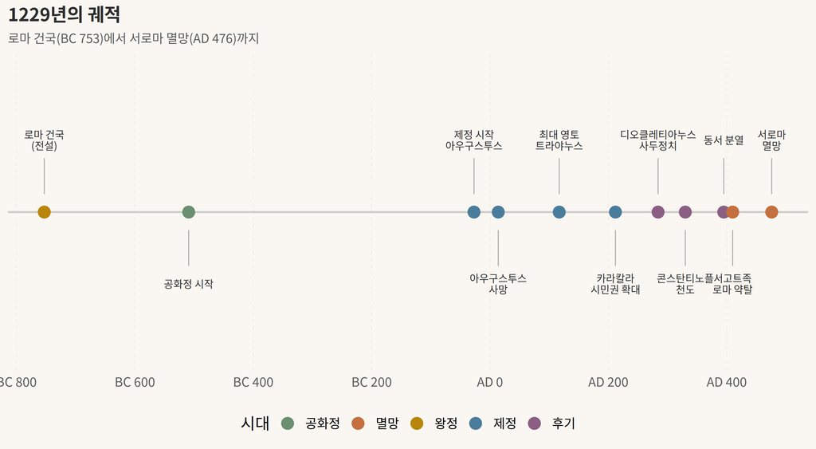

로마 제국 주요 분기점 — 건국에서 최후까지

## 장면 하나 — 410년 8월의 3일

서기 410년 8월 24일. 서고트족의 왕 알라리크가 로마 성문을 열었다. 800년 만에 외부 세력이 로마 시내에 진입한 것이다. 약탈은 3일간 이어졌다.

여기서 놀라운 것은 약탈 자체가 아니다. 알라리크는 원래 로마의 동맹이었다. 서고트족은 로마 제국의 변경에서 수십 년간 용병으로 복무한 사람들이다. 그들이 원한 것은 파괴가 아니었다. **정착할 땅과 식량**, 그리고 약속된 보수. 로마 조정이 그것을 주지 않았을 때, 칼이 뽑혔다.

BBC의 2025년 다큐멘터리 ’Civilisations: Rise and Fall’은 이 장면에서 시작한다. 고트족은 원래 로마의 국경 바깥에서 평화롭게 살던 사람들이었다. 훈족의 서진에 밀려 로마로 피난 온 이들에게 로마는 제국 내부 거주를 허락했지만, 통합하지 않았다. 착취하고, 차별하고, 식량을 끊었다. 난민 위기를 관리하는 데 실패한 것이다.

2025년 유럽을 보라. 지중해를 건너는 보트 위의 사람들. 국경을 닫을 것인가, 열 것인가. 통합할 것인가, 격리할 것인가. 1600년 전과 똑같은 질문이다. 로마는 답을 잘못 골랐고, 그 대가는 문명의 종말이었다.

## 무너지는 데는 이유가 하나가 아니다

로마가 왜 멸망했느냐는 질문에 역사가들은 210가지가 넘는 이론을 제시해 왔다. 납중독, 기후변화, 전염병, 기독교, 군사력 약화, 재정 파탄, 이민족 침입… 어느 하나도 틀리지 않지만, 어느 하나도 완전하지 않다.

핵심은 이것이다: **시스템이 복잡해질수록, 실패도 복합적이 된다.**

에드워드 기번이 18세기에 쓴 ’로마제국 쇠망사’는 6권짜리 대서사시다. 1776년에 첫 권을 냈으니, 미국 독립선언서와 같은 해다. 우연이 아니다. 기번은 로마의 몰락을 쓰면서 동시에 “우리도 그렇게 될 수 있다”는 경고장을 쓰고 있었다.

기번이 지목한 4대 원인 — 콘스탄티노플 천도, 기독교의 확산, 이민족 침입, 지도자의 질적 하락. 이것을 오늘의 언어로 번역하면 이렇다:

- **중심의 이동** — 수도가 옮겨지면 관심도 옮겨진다
- **가치관의 전환** — 기존 시스템의 정당성이 흔들린다
- **외부 충격** — 대응 능력이 약해진 시점에 찾아온다
- **리더십의 실종** — 시스템을 유지할 사람이 사라진다

어디서 많이 본 패턴 아닌가.

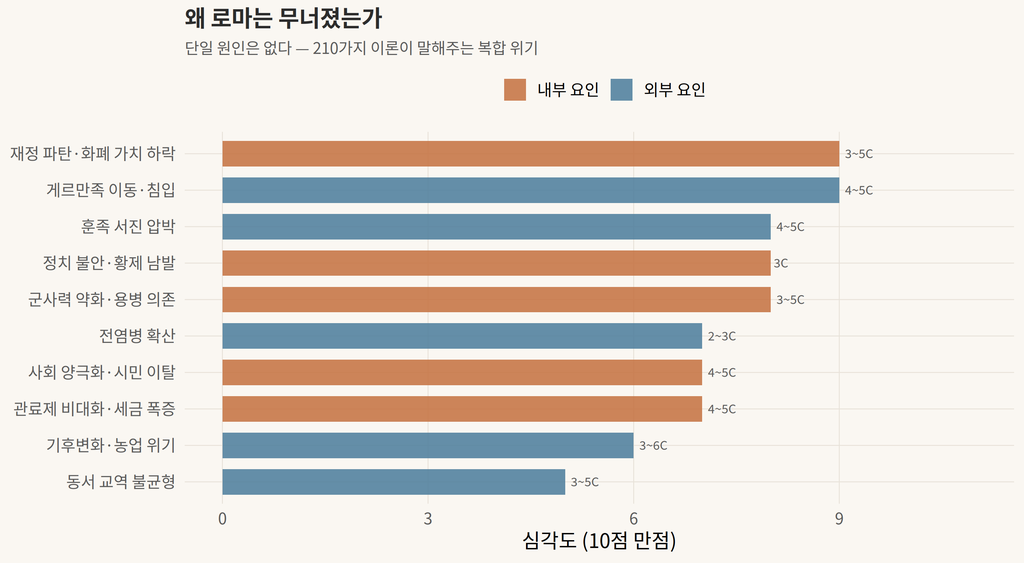

로마 제국 쇠퇴 요인 — 복합적 위기의 구조

## 화폐가 말하는 진실

로마 멸망론 중에서 가장 설득력 있는 것 하나를 꼽으라면, 나는 **화폐**를 고른다.

아우구스투스 시대의 데나리우스 은화에는 순은 함량이 95%에 달했다. 200년 뒤, 셉티미우스 세베루스 시대에는 50%로 떨어졌다. 3세기 위기 때는 5% 이하. 동전을 자세히 보면, 제국의 건강 상태가 보인다.

화폐 가치의 하락은 곧 신뢰의 하락이다. 상인은 물물교환으로 돌아갔고, 세금은 현물로 걷어야 했다. 도시는 쪼그라들었고, 장거리 교역은 무너졌다. 도로는 여전히 있었지만, 그 위를 흐르는 것이 달라졌다. 상품 대신 군대가, 정보 대신 공포가 이동했다.

오늘날의 비유가 가능하다. 달러의 기축통화 지위가 흔들리면? 비트코인이 제도권 화폐를 대체하기 시작하면? 신뢰 시스템의 붕괴가 문명 전체를 어떻게 바꾸는지 — 로마는 실시간 시연을 보여준 셈이다.

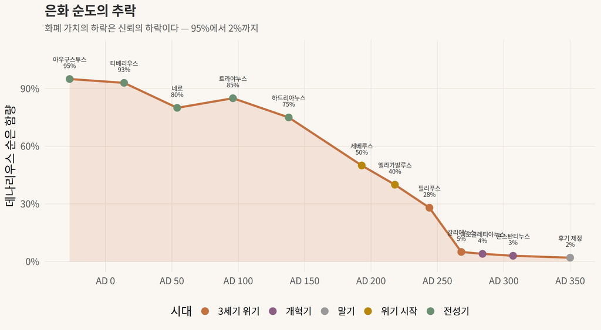

데나리우스 은화의 순은 함량 변화 — 제국의 체온계

## 다큐멘터리 가이드 — 무엇을 볼 것인가

로마를 다룬 영상 콘텐츠는 넘쳐난다. 하지만 시간이 유한한 사람을 위해, 진짜로 볼 만한 것만 추린다.

**다큐멘터리**

- **BBC ‘Civilisations: Rise and Fall’ (2025)** — 가장 최신이자 가장 현대적인 시선. 로마의 고트족 수용과 배제를 오늘의 난민 위기와 직접 연결한다. CGI 복원과 드론 촬영이 압도적이다.
- **BBC ‘Ancient Rome: The Rise and Fall of an Empire’ (2006)** — IMDb 7.9. 재현 드라마와 전문가 인터뷰를 교차 편집한 클래식. 카이사르, 네로, 콘스탄티누스 편이 백미다.
- **Netflix ‘Roman Empire’ (2016-2019)** — IMDb 7.1. 숀 빈의 나레이션이 매력적이지만, 역사적 정확도보다는 드라마성에 방점. 입문용으로 좋다.
- **Mary Beard의 ‘Rome: Empire Without Limit’** — Apple TV+. 케임브리지 교수가 직접 유적지를 걸으며 설명하는, 가장 학술적이면서도 가장 재미있는 시리즈.

**드라마**

- **HBO ‘Rome’ (2005-2007)** — 역사 드라마의 교과서. 제프 빌의 에미상 후보에 오른 사운드트랙은 대편성 오케스트라 대신 로마 제국 변방의 민속 악기를 활용해 독특한 질감을 만들어냈다.

### 시청 추천 순서

처음이라면: Netflix → BBC 2006 → Mary Beard → BBC 2025 깊이 들어가고 싶다면: Mary Beard → BBC 2025 → HBO Rome → 기번의 원전

## YouTube에서 만나는 로마

[video not shown]

BBC Ancient Rome: The Rise and Fall of an Empire

[video not shown]

The Entire History of the Roman Empire

## Spotify에서 듣는 로마

HBO ‘Rome’ 사운드트랙을 들으며 이 글을 읽어보시길. 제프 빌은 거대한 오케스트라 대신 고대 지중해의 악기 — 우드, 타블라, 리라 — 를 사용해 로마의 질감을 재현했다. 화려하지 않지만, 먼지와 피와 대리석 냄새가 난다.

[interactive chart not shown]

## 오늘 우리는 어디에 서 있는가

로마의 붕괴를 공부할수록, 자꾸 오늘이 보인다.

- 화폐 신뢰의 위기 → 양적 완화, 국가 부채, 암호화폐의 부상
- 변경의 이민자 문제 → 유럽 난민 위기, 미국-멕시코 국경
- 군대의 용병화 → 민간군사기업의 확대, 무인 무기 의존
- 시민의 이탈 → 투표율 하락, 정치적 냉소, “나 하나 빠져도”
- 중앙의 약화와 지방의 독립 → EU 내 분열, 지역주의 대두

이것을 “로마와 우리가 닮았다”는 단순 비유로 읽지 말자. 핵심은 닮음이 아니라 **구조**다. 복잡한 시스템은 비슷한 패턴으로 취약해진다. 내부 결속이 먼저 약해지고, 그 다음에 외부 충격이 치명타를 날린다. 순서는 늘 이쪽에서 저쪽으로다.

로마가 남긴 가장 큰 교훈은 이것이다: **제국은 외부의 적에 의해 무너지지 않는다. 내부의 신뢰가 먼저 증발한다.**

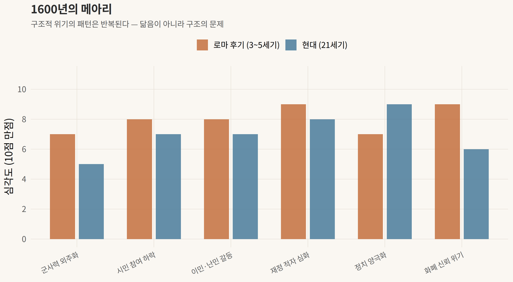

로마 제국 후기 vs 현대 사회 — 구조적 유사성

## 이미지 갤러리 — 제국의 잔해 위에서

[figure not shown]

콜로세움 — 5만 명을 수용한 오락 시스템. 빵과 서커스의 물리적 증거.

[figure not shown]

판테온 내부 — 2000년 된 콘크리트 돔. 현대 건축가도 경탄하는 기술.

[figure not shown]

아피아 가도 — “모든 길은 로마로 통한다”의 물리적 증거. 여전히 걸을 수 있다.

[figure not shown]

포로 로마노 — 원로원이 있던 자리. 민주주의와 독재가 공존했던 광장.

## 나가며 — 경고문은 항상 아름답다

로마의 유적은 아름답다. 콜로세움에 석양이 내리면 인스타그램 감성이 폭발하고, 판테온의 오쿨루스에서 쏟아지는 빛은 신비롭기까지 하다.

하지만 아름다움에 속으면 안 된다. 그 돌들은 경고문이다. “우리는 최강이었다. 영원할 줄 알았다. 그런데 아니었다.”

1776년 기번이 로마의 폐허를 걸으며 ’쇠망사’를 구상했을 때, 대영제국은 전성기를 향해 달리고 있었다. 그리고 그 대영제국도, 결국 같은 길을 걸었다.

오늘 세계 최강국의 수도 워싱턴 D.C.에는 로마식 원주와 아치가 서 있다. 의사당, 대법원, 링컨 기념관. 건축 양식을 빌려온 것일까, 아니면 운명도 함께 빌려온 것일까.

로마는 대답하지 않는다. 다만 돌 위에 새겨진 글자처럼, 조용히 거기 있을 뿐이다.